# Lab 3

## 1. Create a multivariate time series; perform any interpolations.

```r
vars <- c("year", "conpress", "sex", "age", "degree", "wrkstat")
GSS <- data.table::fread("/Users/hengyuai/Desktop/TS/Lab3/trends-gss.csv",
  sep = ",",
  select = vars,
  data.table = FALSE)


sub <- GSS[, vars]
sub = as.data.frame(sub)

sub <- mutate(sub,
              trustpress = ifelse(conpress < 3, 1, 0),
              baplus = ifelse(degree >= 3, 1, 0),
              degreelt50 = ifelse(baplus == 1 & age < 50, 1, 0),
              fulltime = ifelse(wrkstat == 1, 1, 0))
```

```r
## My QUESTION is: Are people's confidence in the press and their working status related over time in the way they are related cross-nationally and at the individual level?

# get means by year
by.year <- aggregate(subset(sub, sel = -year), list(year = sub$year), mean, na.rm = T)

# interpolate for some missing years
# add the extra years
by.year[30:40, "year"] <- c(1979, 1981, 1992, 1995, seq(1997, 2009, 2))
by.year <- arrange(by.year, year)

# make a time series object by.year.ts and interpolate using na.approx
by.year.ts <- ts(by.year)
by.year.ts <- na.approx(by.year.ts)
```

```r
# calculate percent tvholic and percent under 50 with BA
by.year.ts <- as.data.frame(by.year.ts)
by.year.ts <- mutate(by.year.ts,
                     fulltime_pct = fulltime*100,
                     degreelt50_pct = degreelt50*100)

# only keep up to 1992 and convert back to time series object
by.year.ts <- ts(subset(by.year.ts, year <= 1992))

# correlations
cor.vars <- c("trustpress", "fulltime_pct", "degreelt50_pct", "age", "year")
cor.dat <- by.year.ts[, cor.vars]
cor(cor.dat, use = "complete")
```

```
##                trustpress fulltime_pct degreelt50_pct        age
## trustpress      1.0000000   -0.4804851     -0.9281833 -0.6562911
## fulltime_pct   -0.4804851    1.0000000      0.5796194  0.3590326
## degreelt50_pct -0.9281833    0.5796194      1.0000000  0.6255061
## age            -0.6562911    0.3590326      0.6255061  1.0000000
## year           -0.9250063    0.6809984      0.9177727  0.7119450
##                      year
## trustpress     -0.9250063
## fulltime_pct    0.6809984
## degreelt50_pct  0.9177727
## age             0.7119450
## year            1.0000000
```

## 2. Graph the relationships between X and Y. Explain how you think Y should relate to your key Xs.

```r
# Time series plots with ggplot
# install.packages("reshape2")

# Make a character vector naming the variables we might want to plot
keep.vars <- c("year", "trustpress", "fulltime_pct", "degreelt50_pct", "age")

# Use meltMyTS to transform the data to a 3-column dataset containing a column for time, a column for variable names, and a column of values corresponding to the variable names

library("reshape2")

meltMyTS <- function(mv.ts.object, time.var, keep.vars){
  # mv.ts.object = a multivariate ts object
  # keep.vars = character vector with names of variables to keep
  # time.var = character string naming the time variable
  require(reshape2)

  if(missing(keep.vars)) {
    melt.dat <- data.frame(mv.ts.object)
  }
  else {
    if (!(time.var %in% keep.vars)){
      keep.vars <- c(keep.vars, time.var)
    }
    melt.dat <- data.frame(mv.ts.object)[, keep.vars]
  }
  melt.dat <- melt(melt.dat, id.vars = time.var)
  colnames(melt.dat)[which(colnames(melt.dat) == time.var)] <- "time"
  return(melt.dat)
}

plot.dat <- meltMyTS(mv.ts.object = by.year.ts, time.var = "year", keep.vars = keep.vars)
plot.dat
```

```
##    time       variable      value
## 1  1972     trustpress         NA
## 2  1973     trustpress  0.8510494
## 3  1974     trustpress  0.8229665
## 4  1975     trustpress  0.8162275
## 5  1976     trustpress  0.8202324
## 6  1977     trustpress  0.8419290
## 7  1978     trustpress  0.7994670
## 8  1979     trustpress  0.8108992
## 9  1980     trustpress  0.8223315
## 10 1981     trustpress  0.8103347
## 11 1982     trustpress  0.7983380
## 12 1983     trustpress  0.7602302
## 13 1984     trustpress  0.7716371
## 14 1985     trustpress  0.7561245
```

[output cut: 70 more lines]

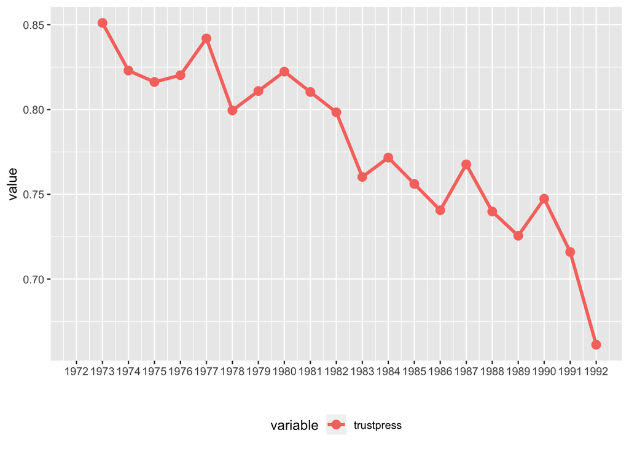

```r
ggMyTS <- function(df, varlist, line = TRUE, point = TRUE, pointsize = 3, linewidth = 1.25, ...){
  require(ggplot2)
  # varlist = character vector with names of variables to use
  if(missing(varlist)){
    gg <- ggplot(df, aes(time, value, colour = variable))
  }
  else{
    include <- with(df, variable %in% varlist)
    gg <- ggplot(df[include,], aes(time, value, colour = variable))
  }
  if(line == FALSE & point == FALSE) {
    stop("At least one of 'line' or 'point' must be TRUE")
  }
  else{
    if(line == TRUE) gg <- gg + geom_line(size = linewidth, aes(color = variable), ...)
    if(point == TRUE) gg <- gg + geom_point(size = pointsize, aes(color = variable), ...)
  }

  gg + xlab("") + theme(legend.position = "bottom") + scale_x_continuous(breaks = min(df$time):max(df$time))
}

(g_trustpress <- ggMyTS(df = plot.dat, varlist = c("trustpress")))
```

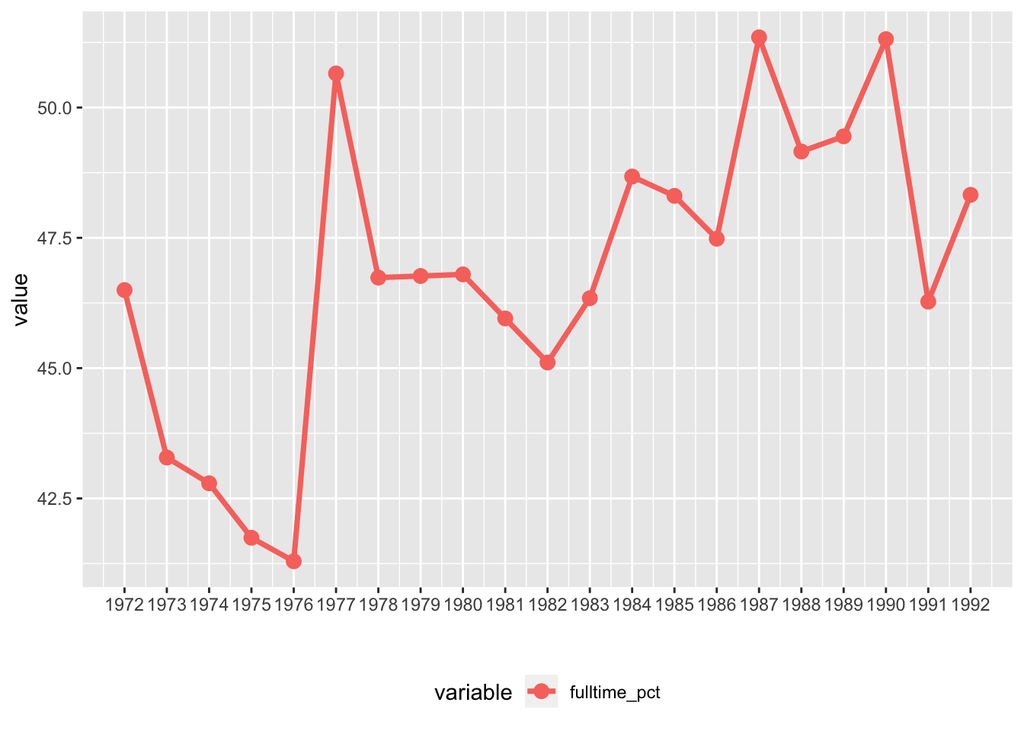

```r
(g_tvholicpct <- ggMyTS(df = plot.dat, varlist = c("fulltime_pct")))
```

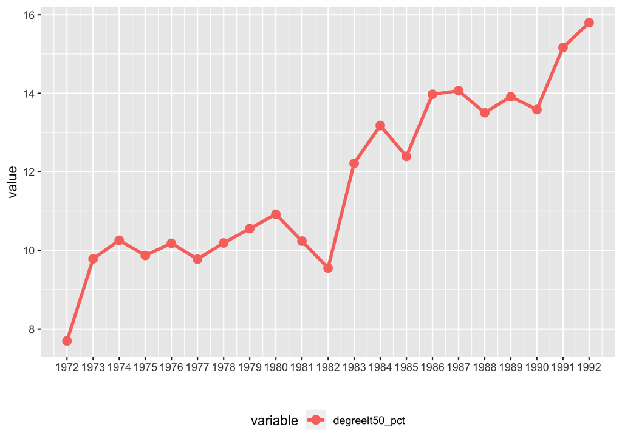

```r
(g_degreelt50_pct <- ggMyTS(df = plot.dat, varlist = c("degreelt50_pct")))
```

Explain how you think Y should relate to your key Xs: From the graphs above, we can find that the percentage of people who have fulltime jobs and the percentage of people who with at least a BA increased between 1972 and 1992 overall. However, people’s average confidence in press declined. Therefore, I think that people’s average confidence in press was negatively related to the percentage of people with fulltime jobs and a BA under 50.

## 3. Run a simple time series regression, with one X and no trend. Interpret it.

```r
# simplest regression
lm.trust <- lm(trustpress ~ fulltime_pct, data = by.year.ts)
summary(lm.trust)
```

```
##
## Call:
## lm(formula = trustpress ~ fulltime_pct, data = by.year.ts)
##
## Residuals:
##      Min       1Q   Median       3Q      Max
## -0.10638 -0.02173  0.00428  0.02386  0.09262
##
## Coefficients:
##               Estimate Std. Error t value Pr(>|t|)
## (Intercept)   1.149076   0.159507   7.204 1.05e-06 ***
## fulltime_pct -0.007892   0.003395  -2.324    0.032 *
## ---
## Signif. codes:  0 '***' 0.001 '**' 0.01 '*' 0.05 '.' 0.1 ' ' 1
##
## Residual standard error: 0.04365 on 18 degrees of freedom
##   (1 observation deleted due to missingness)
## Multiple R-squared:  0.2309, Adjusted R-squared:  0.1881
## F-statistic: 5.403 on 1 and 18 DF,  p-value: 0.032
```

The percent people working full-time was negatively related to average confidence in press. The coefficient is statistically significant at 0.05 and we can reject the null of no effect.

```r
# test for heteroskedasticity
bptest(lm.trust)
```

```
##
##  studentized Breusch-Pagan test
##
## data:  lm.trust
## BP = 1.3552, df = 1, p-value = 0.2444
```

There is no heteroskadasticity from the above regression.

## 4. Run a time series regression with one X and trend. Interpret it. Perform autocorrelation diagnostics. Explain what you found.

```r
lm.trust2 <- update(lm.trust, ~ . + year)
summary(lm.trust2)
```

```
##
## Call:
## lm(formula = trustpress ~ fulltime_pct + year, data = by.year.ts)
##
## Residuals:
##       Min        1Q    Median        3Q       Max
## -0.037563 -0.008056 -0.000676  0.011149  0.022925
##
## Coefficients:
##                Estimate Std. Error t value Pr(>|t|)
## (Intercept)  18.6597301  1.6684148  11.184 2.93e-09 ***
## fulltime_pct  0.0045776  0.0017436   2.625   0.0177 *
## year         -0.0091275  0.0008691 -10.502 7.51e-09 ***
## ---
## Signif. codes:  0 '***' 0.001 '**' 0.01 '*' 0.05 '.' 0.1 ' ' 1
##
## Residual standard error: 0.01641 on 17 degrees of freedom
##   (1 observation deleted due to missingness)
## Multiple R-squared:  0.8973, Adjusted R-squared:  0.8852
## F-statistic: 74.25 on 2 and 17 DF,  p-value: 3.971e-09
```

Net of the year trend, each percent more of full-time employed people increases ave. confidence in press by 0.0045776. This coefficient is significant at 0.05 level and we can reject the null of no effects.

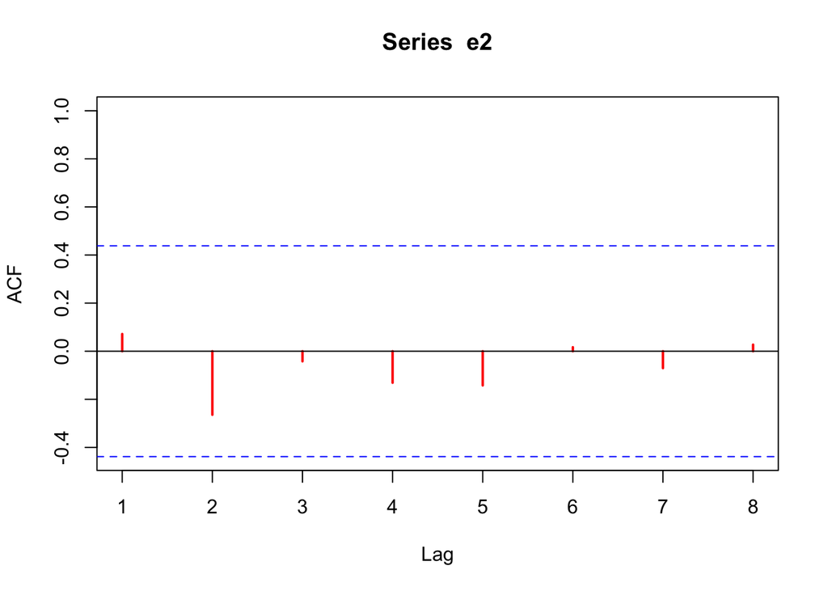

```r
# look for autocorrelation
e2 <- lm.trust2$resid
acf(e2, xlim = c(1,8), col = "red", lwd = 2)
```

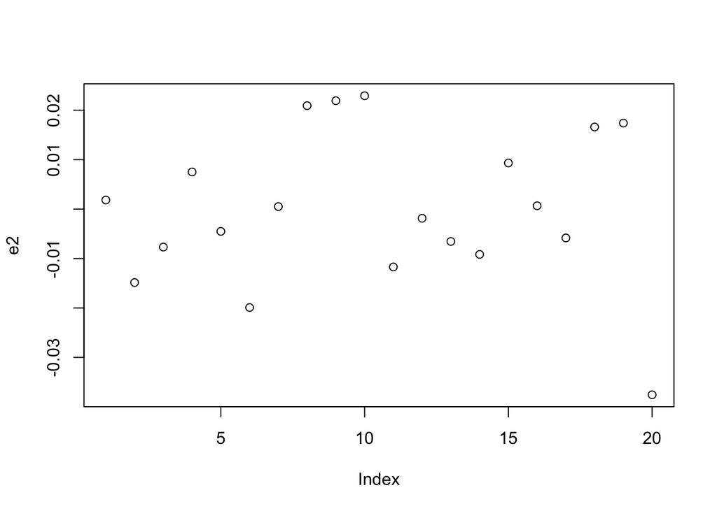

```r
plot(e2)
```

```r
dwtest(lm.trust2)
```

```
##
##  Durbin-Watson test
##
## data:  lm.trust2
## DW = 1.5479, p-value = 0.08736
## alternative hypothesis: true autocorrelation is greater than 0
```

```r
bgtest(lm.trust2)
```

```
##
##  Breusch-Godfrey test for serial correlation of order up to 1
##
## data:  lm.trust2
## LM test = 0.17355, df = 1, p-value = 0.677
```

```r
durbinWatsonTest(lm.trust2, max.lag=3)
```

```
##  lag Autocorrelation D-W Statistic p-value
##    1      0.07160435      1.547916   0.162
##    2     -0.26429238      2.105385   0.842
##    3     -0.04201482      1.587673   0.542
##  Alternative hypothesis: rho[lag] != 0
```

From the ACF graph and residual trend graph, we cannot see any AR(1) left. In the dwtest and bgtest result, a prob of chi2 > 0.05 indicates no serial correlation.

## 5. Consider running a time series regression with many Xs and trend. Interpret that. Check VIF.

```r
lm.trust3 <- update(lm.trust2, ~ . + degreelt50_pct)
summary(lm.trust3)
```

```
##
## Call:
## lm(formula = trustpress ~ fulltime_pct + year + degreelt50_pct,
##     data = by.year.ts)
##
## Residuals:
##       Min        1Q    Median        3Q       Max
## -0.030039 -0.006378 -0.001098  0.009174  0.020660
##
## Coefficients:
##                 Estimate Std. Error t value Pr(>|t|)
## (Intercept)    11.958147   3.053569   3.916  0.00123 **
## fulltime_pct    0.003976   0.001543   2.576  0.02029 *
## year           -0.005671   0.001579  -3.592  0.00244 **
## degreelt50_pct -0.010286   0.004117  -2.498  0.02376 *
## ---
## Signif. codes:  0 '***' 0.001 '**' 0.01 '*' 0.05 '.' 0.1 ' ' 1
##
## Residual standard error: 0.01435 on 16 degrees of freedom
##   (1 observation deleted due to missingness)
## Multiple R-squared:  0.9261, Adjusted R-squared:  0.9123
## F-statistic: 66.84 on 3 and 16 DF,  p-value: 2.869e-09
```

Net of the year trend, each percent more of full-time employed people increases ave. confidence in press by 0.003976. This coefficient is significant at 0.05 level and we can reject the null of no effects. Net of the year trend, each percent more of under 50 BA degree people decreases ave. confidence in press by 0.010286. This coefficient is significant at 0.05 level and we can reject the null of no effects.

```r
vif(lm.trust3) # variance inflation factor
```

```
##   fulltime_pct           year degreelt50_pct
##       1.911386       8.048782       6.499728
```

Given such high correlations among variables, we want to look out for multicollinearity, which we might have with year and % of people under 50 with a BA+ degree.

## 6. Run a first differenced time series regression. Interpret that.

```r
firstD <- function(var, group, df){
  bad <- (missing(group) & !missing(df))
  if (bad) stop("if df is specified then group must also be specified")

  fD <- function(j){ c(NA, diff(j)) }

  var.is.alone <- missing(group) & missing(df)

  if (var.is.alone) {
    return(fD(var))
  }
  if (missing(df)){
    V <- var
    G <- group
  }
  else{
    V <- df[, deparse(substitute(var))]
    G <- df[, deparse(substitute(group))]
  }

  G <- list(G)
  D.var <- by(V, G, fD)
  unlist(D.var)
}

by.yearFD <- summarise(data.frame(by.year.ts),
                       trustpress = firstD(trustpress), # using firstD functon from QMSS package
                       age = firstD(age),
                       fulltime_pct = firstD(fulltime_pct),
                       degreelt50_pct = firstD(degreelt50_pct),
                       year = year)

lm.trust4 <- update(lm.trust3, data = by.yearFD)
summary(lm.trust4)
```

```
##
## Call:
## lm(formula = trustpress ~ fulltime_pct + year + degreelt50_pct,
##     data = by.yearFD)
##
## Residuals:
##       Min        1Q    Median        3Q       Max
## -0.045549 -0.011698 -0.001073  0.015786  0.024447
##
## Coefficients:
##                  Estimate Std. Error t value Pr(>|t|)
## (Intercept)     0.8948219  1.7097579   0.523   0.6084
## fulltime_pct    0.0039378  0.0015902   2.476   0.0257 *
## year           -0.0004557  0.0008623  -0.528   0.6049
## degreelt50_pct -0.0066733  0.0054022  -1.235   0.2357
## ---
## Signif. codes:  0 '***' 0.001 '**' 0.01 '*' 0.05 '.' 0.1 ' ' 1
##
## Residual standard error: 0.02022 on 15 degrees of freedom
##   (2 observations deleted due to missingness)
## Multiple R-squared:  0.3871, Adjusted R-squared:  0.2646
## F-statistic: 3.159 on 3 and 15 DF,  p-value: 0.05572
```

For each 1 percentage point change in people working-full time, average confidence in press increases by 0.0039378, net of all other differences in the Xs and at any point in time. This coefficient is significant at 0.05 level and we can reject the null of no effects. For each 1 percentage point change in people getting BA, average confidence in press decreases by 0.0066733, net of all other differences in the Xs and at any point in time. This coefficient is not significant.

## 7. Check your variables for unit roots. Do some tests. Interpret them.

```r
# install.packages("fUnitRoots")
library(fUnitRoots)
adfTest(by.year.ts[,"trustpress"], lags = 0, type="ct")
```

```
##
## Title:
##  Augmented Dickey-Fuller Test
##
## Test Results:
##   PARAMETER:
##     Lag Order: 0
##   STATISTIC:
##     Dickey-Fuller: -2.842
##   P VALUE:
##     0.2516
##
## Description:
##  Fri Nov 29 01:26:37 2019 by user:
```

```r
adfTest(by.year.ts[,"trustpress"], lags = 4, type="ct")
```

```
##
## Title:
##  Augmented Dickey-Fuller Test
##
## Test Results:
##   PARAMETER:
##     Lag Order: 4
##   STATISTIC:
##     Dickey-Fuller: -1.6725
##   P VALUE:
##     0.6971
##
## Description:
##  Fri Nov 29 01:26:37 2019 by user:
```

Either with 0 lag or with 4 lags, p-value is too high to be able to reject the null of Unit Root, therefore, we might have a unit root here.

## 8. Perform an Automatic ARIMA on the residuals from one of your earlier models. Tell me what it says.

```r
library(forecast)
e <- lm.trust$resid
auto.arima(e, trace=TRUE)
```

```
##
##  ARIMA(2,1,2) with drift         : Inf
##  ARIMA(0,1,0) with drift         : -63.006
##  ARIMA(1,1,0) with drift         : -63.08589
##  ARIMA(0,1,1) with drift         : Inf
##  ARIMA(0,1,0)                    : -64.81855
##  ARIMA(1,1,1) with drift         : Inf
##
##  Best model: ARIMA(0,1,0)
```

```
## Series: e
## ARIMA(0,1,0)
##
## sigma^2 estimated as 0.001717:  log likelihood=33.53
## AIC=-65.05   AICc=-64.82   BIC=-64.11
```

auto.arima suggests that the errors from the static model is a random walk and we cannot reject unit root.

## 9. Run an ARIMA that follows from Step 7. Interpret that, too.

```r
xvars.fat <- by.year.ts[,c("fulltime_pct")]

arima.010 <- arima(by.year.ts[,"trustpress"], order = c(0,1,0), xreg = xvars.fat)
summary(arima.010)
```

```
##
## Call:
## arima(x = by.year.ts[, "trustpress"], order = c(0, 1, 0), xreg = xvars.fat)
##
## Coefficients:
##       xvars.fat
##          0.0039
## s.e.     0.0017
##
## sigma^2 estimated as 0.0004906:  log likelihood = 45.43,  aic = -86.86
##
## Training set error measures:
##                       ME       RMSE        MAE       MPE     MAPE
## Training set -0.01044549 0.02158966 0.01621065 -1.425352 2.157985
##                   MASE       ACF1
## Training set 0.7558092 -0.1133399
```

Each 1 percentage point difference in the percent of people with full-time job increases people’s confidence in press by 0.0039 percentage points.